# Dean’s Dilemma Case Study

Prince Barai

February 3, 2018

# 1. Set the working directory.

```r
setwd("C:/Users/prince_pratik7/Desktop/Machine Learning/Data Analytics/Data Visualisation/Day 6")
```

# 2. Read the dataset using the read.csv() function.

```r
dilemna <- read.csv(paste("Data - Deans Dilemma.csv" , sep = ""))
```

# 3. Use the View() function to view the dataframe created in the previous step.

```r
View(dilemna)
```

# 4. Describing the Dataset

```r
library(psych)
describe(dilemna)
```

```
##                     vars   n      mean        sd    median   trimmed
## SlNo                   1 391    196.00    113.02    196.00    196.00
## Gender*                2 391      1.68      0.47      2.00      1.72
## Gender.B               3 391      0.32      0.47      0.00      0.28
## Percent_SSC            4 391     64.65     10.96     64.50     64.76
## Board_SSC*             5 391      2.23      0.87      3.00      2.28
## Board_CBSE             6 391      0.29      0.45      0.00      0.24
## Board_ICSE             7 391      0.20      0.40      0.00      0.12
## Percent_HSC            8 391     63.80     11.42     63.00     63.34
## Board_HSC*             9 391      2.39      0.85      3.00      2.48
## Stream_HSC*           10 391      2.34      0.56      2.00      2.36
## Percent_Degree        11 391     62.98      8.92     63.00     62.91
## Course_Degree*        12 391      3.85      1.61      4.00      3.81
## Degree_Engg           13 391      0.09      0.29      0.00      0.00
## Experience_Yrs        14 391      0.48      0.67      0.00      0.36
## Entrance_Test*        15 391      5.85      1.35      6.00      6.08
## S.TEST                16 391      0.83      0.38      1.00      0.91
## Percentile_ET         17 391     54.93     31.17     62.00     56.87
## S.TEST.SCORE          18 391     54.93     31.17     62.00     56.87
## Percent_MBA           19 391     61.67      5.85     61.01     61.45
## Specialization_MBA*   20 391      1.47      0.56      1.00      1.42
## Marks_Communication   21 391     60.54      8.82     58.00     59.68
## Marks_Projectwork     22 391     68.36      7.15     69.00     68.60
## Marks_BOCA            23 391     64.38      9.58     63.00     64.08
## Placement*            24 391      1.80      0.40      2.00      1.87
## Placement_B           25 391      0.80      0.40      1.00      0.87
## Salary                26 391 219078.26 138311.65 240000.00 217011.50
##                          mad   min       max     range  skew kurtosis
## SlNo                  145.29  1.00    391.00    390.00  0.00    -1.21
## Gender*                 0.00  1.00      2.00      1.00 -0.75    -1.45
## Gender.B                0.00  0.00      1.00      1.00  0.75    -1.45
## Percent_SSC            12.60 37.00     87.20     50.20 -0.06    -0.72
## Board_SSC*              0.00  1.00      3.00      2.00 -0.45    -1.53
## Board_CBSE              0.00  0.00      1.00      1.00  0.93    -1.14
## Board_ICSE              0.00  0.00      1.00      1.00  1.52     0.31
## Percent_HSC            13.34 40.00     94.70     54.70  0.29    -0.67
## Board_HSC*              0.00  1.00      3.00      2.00 -0.83    -1.13
## Stream_HSC*             0.00  1.00      3.00      2.00 -0.12    -0.72
## Percent_Degree          8.90 35.00     89.00     54.00  0.05     0.24
## Course_Degree*          1.48  1.00      7.00      6.00  0.00    -1.08
```

[output cut: 26 more lines]

```
## Course_Degree*         0.08
## Degree_Engg            0.01
## Experience_Yrs         0.03
## Entrance_Test*         0.07
## S.TEST                 0.02
## Percentile_ET          1.58
## S.TEST.SCORE           1.58
## Percent_MBA            0.30
## Specialization_MBA*    0.03
## Marks_Communication    0.45
## Marks_Projectwork      0.36
## Marks_BOCA             0.48
## Placement*             0.02
## Placement_B            0.02
## Salary              6994.72
```

# 5. Calculate the median salary of all the students in the dataset.

```r
median(dilemna$Salary , na.rm = FALSE)
```

```
## [1] 240000
```

# 6. Calculate the percentage of students who were placed upto 2 decimal places.

```r
percent <- length(dilemna$Placement[dilemna$Placement == "Placed"]) / length(dilemna$Placement) * 100
options(digits = 4)
percent
```

```
## [1] 79.8
```

# 7. Create a dataframe called “placed”, that contains a subset of only those students who were successfully placed.

```r
placed <- subset(dilemna , Placement == "Placed" , select = c(Percent_MBA , Gender , Salary))
placed
```

```
##     Percent_MBA Gender Salary
## 1         58.80      M 270000
## 2         66.28      M 200000
## 3         52.91      M 240000
## 4         57.80      M 250000
## 5         59.43      M 180000
## 6         56.81      M 300000
## 7         59.80      F 260000
## 8         57.23      M 235000
## 9         55.50      M 425000
## 10        63.83      F 240000
## 12        54.01      M 250000
## 13        51.58      M 180000
## 14        66.92      M 428000
## 15        58.21      M 450000
```

[output cut: 298 more lines]

# 8. Calculate median salary of students who were placed.

```r
median(dilemna$Salary[dilemna$Placement == "Placed"] , na.rm = FALSE)
```

```
## [1] 260000
```

# 9. Create a table showing the mean salary of males and females, who were placed

```r
agg.data <- aggregate(Salary ~ Gender + Placement , data = dilemna , mean)
agg.data
```

```
##   Gender  Placement Salary
## 1      F Not Placed      0
## 2      M Not Placed      0
## 3      F     Placed 253068
## 4      M     Placed 284242
```

# 10. Generate a histogram showing a breakup of MBA performance of the students who were placed.

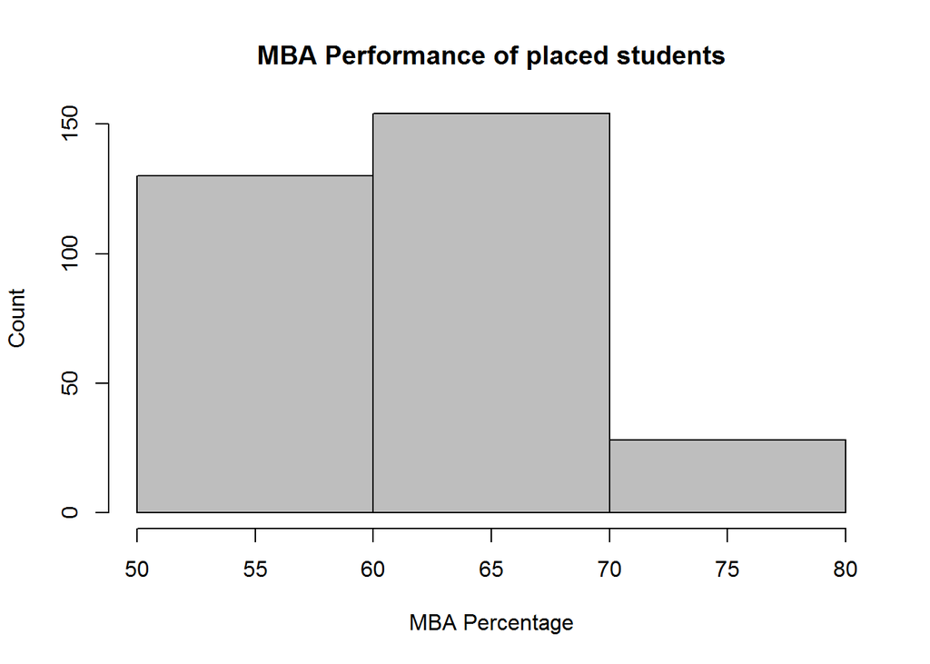

```r
hist(placed$Percent_MBA , main = "MBA Performance of placed students" , xlab = "MBA Percentage" , ylab = "Count" , xlim = c(50,80) , ylim = c(0,150) , col = "grey" , breaks = c(50,seq(60,80,10)))
```

# 11. Create a dataframe called “notplaced”, that contains a subset of only those students who were not placed after their MBA.

```r
notplaced <- subset(dilemna , Placement == "Not Placed" , select = c(Percent_MBA , Gender , Salary))
notplaced
```

```
##     Percent_MBA Gender Salary
## 11        69.78      F      0
## 16        53.29      F      0
## 20        54.65      M      0
## 40        67.28      F      0
## 42        51.75      F      0
## 43        56.34      M      0
## 59        51.29      M      0
## 64        52.56      M      0
## 68        51.45      M      0
## 75        51.21      M      0
## 79        71.63      F      0
## 82        56.11      F      0
## 88        56.19      M      0
## 89        65.49      F      0
```

[output cut: 65 more lines]

# 12. Draw two histograms side-by-side, visually comparing the MBA performance of Placed and Not Placed students.

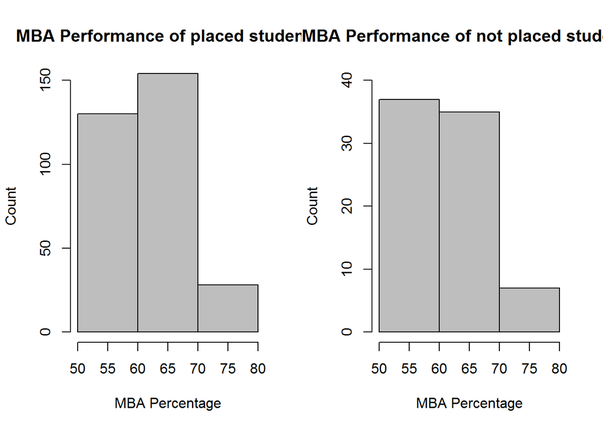

```r
par(mfrow = c(1,2))

hist(placed$Percent_MBA , main = "MBA Performance of placed students" , xlab = "MBA Percentage" , ylab = "Count" , xlim = c(50,80) , ylim = c(0,150) , col = "grey" , breaks = c(50,seq(60,80,10)))

hist(notplaced$Percent_MBA , main = "MBA Performance of not placed students" , xlab = "MBA Percentage" , ylab = "Count" , xlim = c(50,80) , ylim = c(0,40) , col = "grey" , breaks = c(50,seq(60,80,10)))
```

```r
par(mfrow = c(1,1))
```

# 13. Draw two boxplots, one below the other, comparing the distribution of salaries of males and females who were placed.

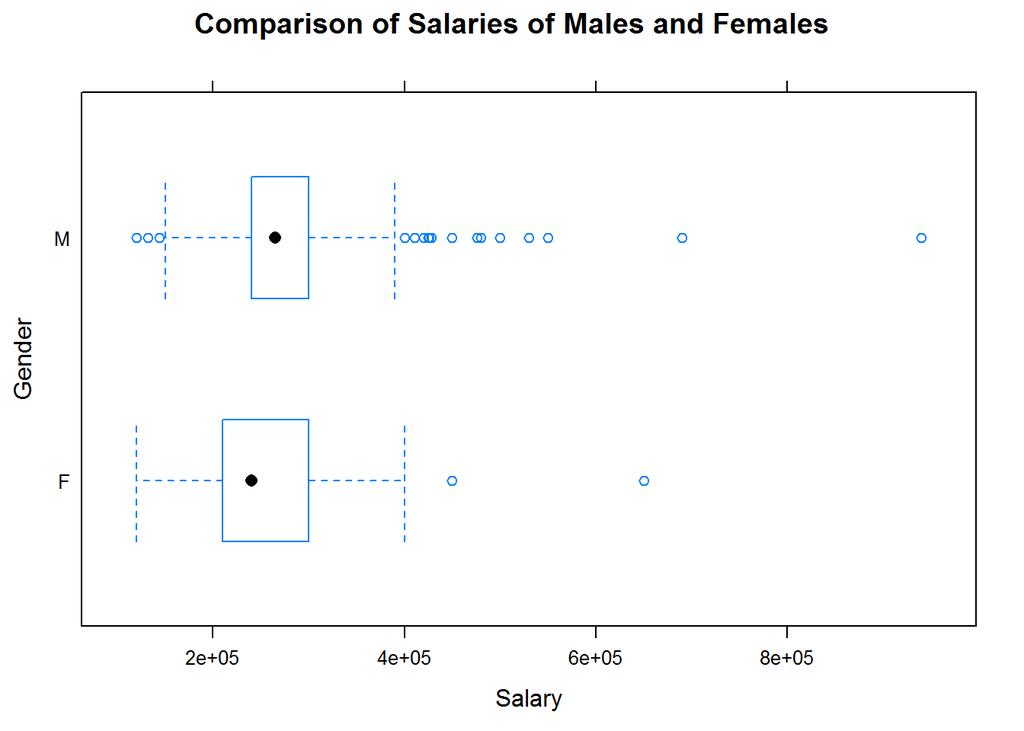

```r
library(lattice)
bwplot(Gender ~ Salary , data = placed , horizontal = TRUE , xlab = "Salary" , ylab = "Gender" , main = "Comparison of Salaries of Males and Females")
```

# 14. Create a dataframe called placedET, representing students who were placed after the MBA and who also gave some MBA entrance test before admission into the MBA program.

```r
placedET <- subset(dilemna , Placement == "Placed" & S.TEST == 1 , select = c(Salary , Percent_MBA , Percentile_ET))
placedET
```

```
##     Salary Percent_MBA Percentile_ET
## 1   270000       58.80         55.00
## 2   200000       66.28         86.50
## 4   250000       57.80         75.00
## 5   180000       59.43         66.00
## 8   235000       57.23         43.12
## 9   425000       55.50         96.80
## 12  250000       54.01         79.00
## 13  180000       51.58         55.00
## 15  450000       58.21         33.00
## 19  252000       62.14         67.00
## 21  280000       63.26         70.00
## 22  231000       61.29         91.34
## 23  224000       62.51         35.00
## 24  120000       52.21         54.00
```

[output cut: 247 more lines]

# 15. Draw a Scatter Plot Matrix for 3 variables - {Salary, Percent_MBA, Percentile_ET} using the dataframe placedET.

```r
library(psych)
library(car)
```

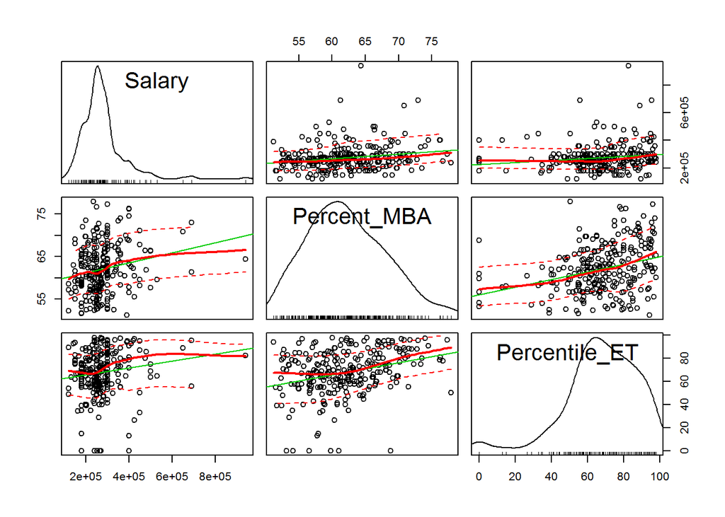

```r
scatterplotMatrix(formula = ~ Salary + Percent_MBA + Percentile_ET, data = placedET)
```